```python
import matplotlib.pyplot as plt
from matplotlib import cm
from matplotlib import gridspec
import os
import numpy as np
import csv
import pandas as pd
import matplotlib.colors as colors
from IPython.display import Markdown, display
import matplotlib
import collections
import folium
from textwrap import wrap
import branca
from collections import defaultdict
from folium.plugins import HeatMap, HeatMapWithTime
import seaborn as sns
import ast

# import fancy_plot as fp
%matplotlib inline
```

# Helper functions

```python
def calc_parcels_kpis(folder):

    KPI_fn = "Parcels.csv"
    path = os.path.join(base_path, folder)
    delivered = 0
    with open(os.path.join(path, KPI_fn), 'r') as f:
        parcels = list(csv.reader(f, delimiter=','))
        #print(parcels[0])
        parcels = parcels[1:] #drop the length of array

    time_request, time_picked_up, time_delivered, travel_time_optim, vehicle_pickup = [],[],[],[],[]
    for time in parcels:
        try:
            time_delivered.append(float(time[6]))
            time_request.append(float(time[4]))
            time_picked_up.append(float(time[5]))
            travel_time_optim.append(float(time[7]))
            vehicle_pickup.append(float(time[8]))
            delivered = delivered+1
        except:
            # if parcel is not delivered yet
#             print("sKIPPING BECAUSE OF PROBLEM")
            break


    delivery_time = np.array(time_delivered) - np.array(time_request)
    delay = delivery_time - np.array(travel_time_optim)
    TimeOnVehicle = np.array(time_delivered) - np.array(time_picked_up)
    WaitingToPickUp = np.array(time_picked_up) - np.array(time_request)
    return delivery_time, delay, TimeOnVehicle, WaitingToPickUp, delivered

#returned as list
def calc_parcels_kpis_Mean(folder):
    delivery_time, delay, TimeOnVehicle, WaitingToPickUp, delivered = calc_parcels_kpis(folder)
    return (np.mean(delivery_time), np.mean(delay), np.mean(TimeOnVehicle), np.mean(WaitingToPickUp))


def calc_driven_distance_flex(folder, steps, n_vehicles):
    # returns m
    dirpath = os.path.join(base_path,folder + "/vehicles")
    time_list = np.linspace(time_first, time_last, int((time_last-time_first)/steps+1))[:-2]
#     if steps == 140:
#         filename = 'vehicles-47180.txt'
#     else:
    filename = 'vehicles-{}.txt'.format(int((time_list[-1:])[0]))
    veh_current = []

    with open(os.path.join(dirpath, filename), 'r') as txt:
        all_txt = txt.read()
        lines = all_txt.split("#")
        lines.remove(lines[0])
        lines = lines[0].split("\n")
        lines.remove(lines[0])

        for i in lines[:n_vehicles]:
            veh = []
            new = i.split("%")
            if new == ['']:
                break
            else:
                status = new[0].split(" ")
                executed = new[1].split(" ")
                planned = new[2].split(" ")
                occ = new[5]
                distance = new[6]
                while '' in executed: executed.remove('')
                while '' in status: status.remove('')
                while '' in planned: planned.remove('')
                veh.append(executed)
                veh.append(status)
                veh.append(planned)
                veh.append(int(occ))
                veh.append(int(distance))
                veh_current.append(veh)

    tt = 0
    for veh in veh_current:
        dist = veh[4]
        tt += dist
    return tt / 1000 # returns km

# reurns the mean of mean loaded parcels of a run
def mean_parcel(folder, used_vehicles):
    occ_fn = "occuoancy_adv.csv"
    with open(os.path.join(os.path.join(base_path,folder), occ_fn), 'r') as f:
        occ = list(csv.reader(f, delimiter=','))
        occ = occ[1:] #drop the length of array
    occ_rebal, occ_idle, occ_pick = [],[], []
    occ_1, occ_2, occ_3, occ_4, occ_5 = [],[],[],[],[]
    occ_6, occ_7, occ_8, occ_9, occ_10, occ_11 = [],[],[],[],[],[]
    for time in occ:
        i = time[1:]
        occ_rebal.append(i.count("-3"))
        occ_idle.append(i.count("-2"))
        occ_pick.append(i.count("-1"))
        occ_1.append(i.count("1"))
        occ_2.append(i.count("2"))
        occ_3.append(i.count("3"))
        occ_4.append(i.count("4"))
        occ_5.append(i.count("5"))
        occ_6.append(i.count("6"))
        occ_7.append(i.count("7"))
        occ_8.append(i.count("8"))
        occ_9.append(i.count("9"))
        occ_10.append(i.count("10"))
        occ_11.append(i.count("11"))

    mean_parcels = []

    for i, idle in enumerate(occ_idle):
        sum_loaded = occ_1[i] + 2*occ_2[i] + 3*occ_3[i] +  4*occ_4[i] + 5*occ_5[i] + 6*occ_6[i] + 7*occ_7[i]
        #print(sum_loaded)
        mean_parcel_now = sum_loaded/used_vehicles
        mean_parcels.append(mean_parcel_now)
    return np.mean(mean_parcels)


def read_kpi_ignored(folder):
    KPI_fn = "KPIs.csv"
    with open(os.path.join(base_path, folder, KPI_fn), 'r') as f:
        kpi = list(csv.reader(f, delimiter=','))
        #print(kpi[0])
        kpi = kpi #drop the length of array

    pickups, drops, ignored, open_order, rebalancing = [],[],[],[],[]
    for time in kpi:
        ignored.append(int(time[4])/considered_depots) # is calculated based on requests

    return ignored

def rolling_sum(list):
    out = []
    sum= 0
    for i in list:
        sum += i
        out.append(sum)
    return out


def service_rate(folder, total_demand):
    ignored = read_kpi_ignored(folder)
    total_ignored = rolling_sum(ignored)
    return (100-total_ignored[-1:][0]/total_demand*100)

def cost_computer(folder, total_demand, cost_weight, ignore_cost, n_vehicles):
    _,delay,_,_,_ = calc_parcels_kpis(folder)
    delay = np.sum(delay)

    ignored = read_kpi_ignored(folder)
    total_ignored = rolling_sum(ignored)

    sum_dist = calc_driven_distance_flex(folder, 100, n_vehicles)

    cost_total_end = (1-cost_weight)* np.sum(delay) + \
                 cost_weight*sum_dist + \
                 total_ignored[-1:][0] * ignore_cost

    return cost_total_end

def diff_x(x):
    a = []
    for i in range(len(x)):
        if i == 0:
            pass
        else:
            a.append(x[i] - x[0])

    return [0, *a]


def mean_computer(x_list):
    return np.mean(x_list, axis=1)

def printmd(string):
    display(Markdown(string))
```

# Graphing Functions

```python
def load_demand(data_path, input_folder):
    with open(os.path.join(data_path,input_folder,'demand','Demand_basic.csv'), 'r') as f:
        demand = list(csv.reader(f, delimiter=','))
        #print(occ)
        demand = demand[1:] #drop the length of array
        demand_time = []
        demand_long = []
        demand_lat = []
        demand_station = []
        for i in demand:
            demand_time.append(int(i[0].split(" ")[0]))
            demand_long.append(float(i[0].split(" ")[1]))
            demand_lat.append(float(i[0].split(" ")[2]))
            demand_station.append(float(i[0].split(" ")[3]))

    demand_time = np.array(demand_time)
    demand_time = demand_time[(demand_time > time_first) & (demand_time < max_hour)]

    return demand, demand_time

def load_graph_kpis(folder_costs, demand_time):
    total_demand = len(demand_time)

    delivery_time_stores, delay_stores, TimeOnVehicle_stores, WaitingToPickUp_stores, delivered, overall_cost = [],[],[],[],[],[]
    for folder in folder_costs:
        delivery_time_stores.append(calc_parcels_kpis_Mean(folder)[0])
        delay_stores.append(calc_parcels_kpis_Mean(folder)[1])
        TimeOnVehicle_stores.append(calc_parcels_kpis_Mean(folder)[2])
        WaitingToPickUp_stores.append(calc_parcels_kpis_Mean(folder)[3])
        delivered.append(calc_parcels_kpis(folder)[4])
        overall_cost.append(cost_computer(folder, total_demand, 0.5, 10000, used_vehicles))


    total_demand = len(demand_time)

    service_rate_stores = []
    for folder in folder_costs:
        service_rate_stores.append(service_rate(folder, total_demand))

    driven_distance_stores = []
    for i, folder in enumerate(folder_costs):
        driven_distance_stores.append(calc_driven_distance_flex(folder, steps, used_vehicles))

    mean_parcels_stores = []
    for folder in folder_costs:
        mean_parcels_stores.append(mean_parcel(folder, used_vehicles))

    return delivery_time_stores, delay_stores, TimeOnVehicle_stores, WaitingToPickUp_stores, delivered, overall_cost, mean_parcels_stores, driven_distance_stores, service_rate_stores

def load_graph_index(delivery_time_stores, delay_stores, TimeOnVehicle_stores, WaitingToPickUp_stores, delivered, overall_cost, mean_parcels_stores, driven_distance_stores, service_rate_stores):
    dif_overall = diff_x(overall_cost)
    dif_delivery = diff_x(delivery_time_stores)
    dif_delay = diff_x(delay_stores)
    dif_veh = diff_x(TimeOnVehicle_stores)
    dif_wait = diff_x(WaitingToPickUp_stores)
    dif_service = diff_x(service_rate_stores)
    dif_dist = diff_x(driven_distance_stores)
    dif_parcels = diff_x(mean_parcels_stores)
    dif_delivery_perorder = diff_x(np.divide(driven_distance_stores,delivered))

    return dif_overall, dif_delivery, dif_delay, dif_veh, dif_wait, dif_service, dif_dist, dif_parcels, dif_delivery_perorder

def bar_computer(folder_costs, label_costs, image_num, delivery_time_stores, delay_stores, TimeOnVehicle_stores, WaitingToPickUp_stores, delivered, overall_cost, mean_parcels_stores, driven_distance_stores, service_rate_stores, dif_overall, dif_delivery, dif_delay, dif_veh, dif_wait, dif_service, dif_dist, dif_parcels, dif_delivery_perorder, color_map):

    bar_width = 1/(len(folder_costs)+1)
#     color_map = cm.get_cmap("viridis", len(folder_costs) - 1)
#     color_map = mcolors.LinearSegmentedColormap.from_list('my_colormap', [*cm.viridis.colors[::25], [1,0,0]])


#     plt.figure(i)
    plt.subplots(figsize=(25,14))

    gs = gridspec.GridSpec(2, 5, width_ratios=[1, 1, 5, 1, 1])
    gs.update(wspace = 0.5)

    plt.subplot(gs[0,0])
    X = np.arange(1)
    for i in range(len(folder_costs)):
        plt.bar(X + i*bar_width, overall_cost[i], color=color_map(i), width=bar_width)
    plt.xticks(X + i*bar_width/2, ("Overall Cost", ))
    plt.ylim(0,max(overall_cost)*1.1)
    plt.ylabel("Cost [s]")

    plt.subplot(gs[0,1])
    X = np.arange(1)
    for i in range(len(folder_costs)):
        plt.bar(X + i*bar_width, service_rate_stores[i], color=color_map(i), width=bar_width)
    plt.xticks(X + i*bar_width/2, ("Service rate", ))
    plt.ylim(0,max(service_rate_stores)*1.1)
    plt.ylabel("Percentage [\%]")

    plt.subplot(gs[0,2])
    X = np.arange(4)
    for i in range(len(folder_costs)):
        plt.bar(X + (i*bar_width), (delivery_time_stores[i], delay_stores[i], TimeOnVehicle_stores[i], WaitingToPickUp_stores[i]),\
                color=color_map(i), width=bar_width, label=label_costs[i])
    plt.xticks(X + i*bar_width/2, ("Delivery time", "Delay", "Time on \n vehicle", "Waiting time"))
#     plt.legend(loc='upper right')
    plt.ylim(0,max(*delivery_time_stores,*delay_stores,*TimeOnVehicle_stores,*WaitingToPickUp_stores)*1.1)
    plt.ylabel("Time [s]")

    plt.subplot(gs[0,3])
    X = np.arange(1)
    for i in range(len(folder_costs)):
        plt.bar(X + i*bar_width, mean_parcels_stores[i], color=color_map(i), width=bar_width)
    plt.xticks(X + i*bar_width/2, ("Mean loaded parcels", ))
    plt.ylim(0,max(mean_parcels_stores)*1.1)
    plt.ylabel("Counts")

    plt.subplot(gs[0,4])
    X = np.arange(1)
    for i in range(len(folder_costs)):
        plt.bar(X + (i*bar_width),  driven_distance_stores[i] , color=color_map(i), width=bar_width)
    plt.xticks(X + i*bar_width/2, ("Total driven distance",))
    plt.ylim(0,max(driven_distance_stores)*1.1)
    plt.ylabel("Distance [km]")


#     label_costs = label_costs[1:]
#     color_map = cm.get_cmap("viridis", len(folder_costs))


    plt.subplot(gs[1,0])
    X = np.arange(1)
    for i in range(len(dif_delivery)):
        plt.bar(X + i*bar_width, dif_overall[i], color=color_map(i), width=bar_width)
    plt.xticks(X + i*bar_width/2, ("Overall Costs", ))
    #plt.legend()
    plt.ylabel("Change in cost [\%]")
#     plt.ylim(min(dif_overall)*1.1,max(dif_overall)*1.1)


    plt.subplot(gs[1,1])
    X = np.arange(1)
    for i in range(len(dif_delivery)):
        plt.bar(X + i*bar_width, dif_service[i], color=color_map(i), width=bar_width)
    plt.xticks(X + i*bar_width/2, ("Service rate", ))
    #plt.legend()
    plt.ylabel("Change in percentage [\%]")
#     plt.ylim(min(dif_service)*1.1,max(dif_service)*1.1)
```

```python
    plt.subplot(gs[1,2])
    X = np.arange(4)
    for i in range(len(dif_delay)):
        plt.bar(X + (i*bar_width), (dif_delivery[i], dif_delay[i], dif_veh[i], dif_wait[i]),
                color=color_map(i), width=bar_width, label=label_costs[i])
    plt.xticks(X + i*bar_width/2, ("Delivery time", "Delay", "Time on \n vehicle", "Waiting time"))
    plt.ylim(min(*dif_delivery,*dif_delay,*dif_veh,*dif_wait)*1.1,max(*dif_delivery,*dif_delay,*dif_veh,*dif_wait)*1.5)
    plt.ylabel("Change in time KPIs [s]")
    plt.legend(label_costs, loc="lower center", bbox_to_anchor=(0.5, -0.7), fancybox=True, shadow=False, ncol=2)


    plt.subplot(gs[1,3])
    X = np.arange(1)
    for i in range(len(dif_delay)):
        plt.bar(X + i*bar_width, dif_parcels[i], color=color_map(i), width=bar_width)
    plt.xticks(X + i*bar_width/2, ("Mean loaded parcels", ))
#     plt.ylim(min(dif_parcels)*1.1,max(dif_parcels)*1.1)
    plt.ylabel("Change in loaded parcels")

    plt.subplot(gs[1,4])
    X = np.arange(1)
    for i in range(len(dif_delay)):
        plt.bar(X + i*bar_width, dif_dist[i], color=color_map(i), width=bar_width)
    plt.xticks(X + i*bar_width/2, ("Total driven distance", ))
#     plt.ylim(min(dif_dist)*1.1,max(dif_dist)*1.1)
    plt.ylabel("Change in distance [km]")

    #     plt.savefig(os.path.join(base_path,'output_images','result_'+str(input_folder)+'.png'))
    plt.show()

def bar_box_computer(folder_costs, label_costs, image_num, delivery_time_stores, delay_stores, TimeOnVehicle_stores, WaitingToPickUp_stores, delivered, overall_cost, mean_parcels_stores, driven_distance_stores, service_rate_stores, dif_overall, dif_delivery, dif_delay, dif_veh, dif_wait, dif_service, dif_dist, dif_parcels, color_map):

    bar_width = 1/(len(folder_costs)+1)
#     color_map = cm.get_cmap("viridis", len(folder_costs) - 1)
#     color_map = mcolors.LinearSegmentedColormap.from_list('my_colormap', [*cm.viridis.colors[::25], [1,0,0]])


#     plt.figure(i)
    plt.subplots(figsize=(25,14))

    gs = gridspec.GridSpec(3, 5, width_ratios=[1, 1, 5, 1, 1], height_ratios=[1,1,1])
    gs.update(wspace = 0.5, hspace = 0.4)

    plt.subplot(gs[0,0])
    X = np.arange(1)
    for i in range(len(folder_costs)):
        plt.bar(X + i*bar_width, mean_computer(overall_cost)[i], color=color_map(i), width=bar_width)
    plt.xticks(X + i*bar_width/2, ("Overall Cost", ))
    plt.ylim(0,max(mean_computer(overall_cost))*1.1)
    plt.ylabel("Cost [s]")

    plt.subplot(gs[0,1])
    X = np.arange(1)
    for i in range(len(folder_costs)):
        plt.bar(X + i*bar_width, mean_computer(service_rate_stores)[i], color=color_map(i), width=bar_width)
    plt.xticks(X + i*bar_width/2, ("Service rate", ))
    plt.ylim(0,max(mean_computer(service_rate_stores))*1.1)
    plt.ylabel("Percentage [\%]")

    plt.subplot(gs[0,2])
    X = np.arange(4)
    for i in range(len(folder_costs)):
        plt.bar(X + (i*bar_width), (mean_computer(delivery_time_stores)[i], mean_computer(delay_stores)[i], mean_computer(TimeOnVehicle_stores)[i], mean_computer(WaitingToPickUp_stores)[i]),\
                color=color_map(i), width=bar_width, label=label_costs[i])
    plt.xticks(X + i*bar_width/2, ("Delivery time", "Delay", "Time on \n vehicle", "Waiting time"))
#     plt.legend(loc='upper right')
    plt.ylim(0,max(*mean_computer(delivery_time_stores),*mean_computer(delay_stores),*mean_computer(TimeOnVehicle_stores),*mean_computer(WaitingToPickUp_stores))*1.1)
    plt.ylabel("Time [s]")

    plt.subplot(gs[0,3])
    X = np.arange(1)
    for i in range(len(folder_costs)):
        plt.bar(X + i*bar_width, mean_computer(mean_parcels_stores)[i], color=color_map(i), width=bar_width)
    plt.xticks(X + i*bar_width/2, ("Mean loaded parcels", ))
    plt.ylim(0,max(mean_computer(mean_parcels_stores))*1.1)
    plt.ylabel("Counts")

    plt.subplot(gs[0,4])
    X = np.arange(1)
    for i in range(len(folder_costs)):
        plt.bar(X + (i*bar_width),  mean_computer(driven_distance_stores)[i] , color=color_map(i), width=bar_width)
    plt.xticks(X + i*bar_width/2, ("Total driven distance",))
    plt.ylim(0,max(mean_computer(driven_distance_stores))*1.1)
    plt.ylabel("Distance [km]")


#     label_costs = label_costs[1:]
#     color_map = cm.get_cmap("viridis", len(folder_costs))


    plt.subplot(gs[1,0])
    X = np.arange(1)
    for i in range(len(dif_delivery)):
        plt.bar(X + i*bar_width, mean_computer(dif_overall)[i], color=color_map(i), width=bar_width)
    plt.xticks(X + i*bar_width/2, ("Overall Costs", ))
    #plt.legend()
    plt.ylabel("Change in cost [\%]")
#     plt.ylim(min(dif_overall)*1.1,max(dif_overall)*1.1)


    plt.subplot(gs[1,1])
    X = np.arange(1)
    for i in range(len(dif_delivery)):
        plt.bar(X + i*bar_width, mean_computer(dif_service)[i], color=color_map(i), width=bar_width)
    plt.xticks(X + i*bar_width/2, ("Service rate", ))
    #plt.legend()
    plt.ylabel("Change in percentage [\%]")
#     plt.ylim(min(dif_service)*1.1,max(dif_service)*1.1)


    plt.subplot(gs[1,2])
    X = np.arange(4)
    for i in range(len(dif_delay)):
        plt.bar(X + (i*bar_width), (mean_computer(dif_delivery)[i], mean_computer(dif_delay)[i], mean_computer(dif_veh)[i], mean_computer(dif_wait)[i]),
                color=color_map(i), width=bar_width, label=label_costs[i])
    plt.xticks(X + i*bar_width/2, ("Delivery time", "Delay", "Time on \n vehicle", "Waiting time"))
    plt.ylim(min(*mean_computer(dif_delivery),*mean_computer(dif_delay),*mean_computer(dif_veh),*mean_computer(dif_wait))*1.1,max(*mean_computer(dif_delivery),*mean_computer(dif_delay),*mean_computer(dif_veh),*mean_computer(dif_wait))*1.5)
    plt.ylabel("Change in time KPIs [s]")
    plt.legend(label_costs, loc="lower center", bbox_to_anchor=(0.5, -2.25), fancybox=True, shadow=False, ncol=4)


    plt.subplot(gs[1,3])
    X = np.arange(1)
    for i in range(len(dif_delay)):
        plt.bar(X + i*bar_width, mean_computer(dif_parcels)[i], color=color_map(i), width=bar_width)
    plt.xticks(X + i*bar_width/2, ("Mean loaded parcels", ))
#     plt.ylim(min(dif_parcels)*1.1,max(dif_parcels)*1.1)
    plt.ylabel("Change in loaded parcels")
```

```python
    plt.subplot(gs[1,4])
    X = np.arange(1)
    for i in range(len(dif_delay)):
        plt.bar(X + i*bar_width, mean_computer(dif_dist)[i], color=color_map(i), width=bar_width)
    plt.xticks(X + i*bar_width/2, ("Total driven distance", ))
#     plt.ylim(min(dif_dist)*1.1,max(dif_dist)*1.1)
    plt.ylabel("Change in distance [km]")



    plt.subplot(gs[2,0])
    plt.boxplot(overall_cost)
    plt.xticks([2], ['Overall Cost'])
    plt.ylabel("Cost [s]")


    plt.subplot(gs[2,1])
    plt.boxplot(service_rate_stores)
    plt.xticks([2], ["Service Rate"])
    plt.ylabel("Percentage [\%]")


    plt.subplot(gs[2,2])
    plt.boxplot(delivery_time_box, positions=np.array(range(len(folder_costs))), sym='', widths=0.8)
    plt.boxplot(delay_box, positions=np.array(range(len(folder_costs)))*1+ 4, sym='', widths=0.8)
    plt.boxplot(TimeOnVehicle_box, positions=np.array(range(len(folder_costs)))*1+ 8, sym='', widths=0.8)
    plt.boxplot(WaitingToPickUp_box, positions=np.array(range(len(folder_costs)))*1 + 12, sym='', widths=0.8)
    ticks = ["Delivery time", "Delay", "Time on \n vehicle", "Waiting time"]
    plt.xticks([1,5,9,13], ticks)
    plt.xlim(-1, 16)
    plt.ylabel("Time [s]")


    plt.subplot(gs[2,3])
    plt.boxplot(mean_parcels_stores)
    plt.xticks([2], ["Mean Loaded Parcels"])
    plt.ylabel("Counts")


    plt.subplot(gs[2,4])
    plt.boxplot(driven_distance_stores)
    plt.xticks([2], ["Total driven distance"])
    plt.ylabel("Distance [km]")

    #     plt.savefig(os.path.join(base_path,'output_images','result_'+str(input_folder)+'.png'))
    plt.show()
```

# Method Selection- Rewards Adjustment

In this section we highlight the different techniques of rewards adjustment, and showcase the approach that does the best given a data set that is uniformly distributed in time but has a gaussian distribution in space with respect to the central node of the graph. We also compare our rewards adjustment technique with a lower bound that is the base myopic approach and an upper bound of anticipation set by the perfect anticipation - 200 second lookahead method.

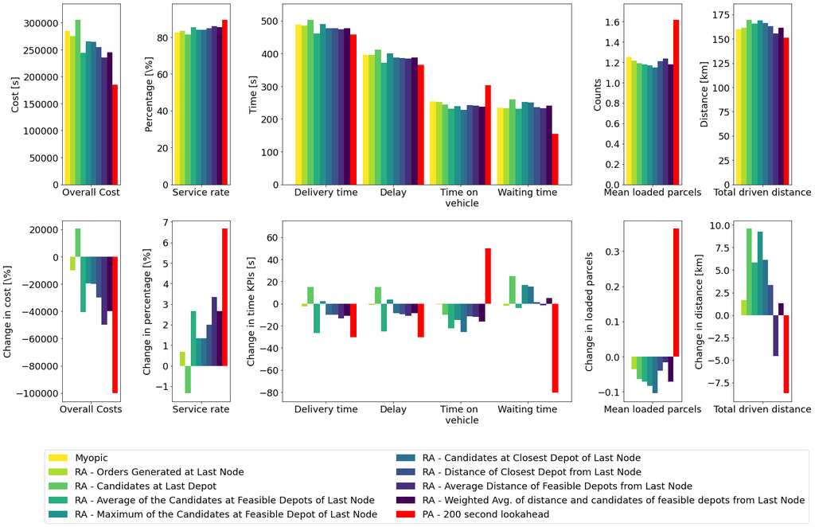

```python
plt.rcParams.update({'font.size': 18})
time_first= 9 *3600
max_hour = 9.5*3600
finishing_time = 15
time_last=max_hour+finishing_time*60
steps = 100
used_vehicles = 10
considered_depots = 5


output_folders_myopic = "19-10-2021_13:49:33"
output_folders_ra_ln = "15-10-2021_13:14:09"
output_folders_ra_in_beforeln = "15-10-2021_15:23:43"
output_folders_ra_in_feasibledepots_mean = "20-10-2021_15:37:39"
output_folders_ra_in_feasibledepots_max = "21-10-2021_11:46:50"
output_folders_ra_in_closestdepot = "20-10-2021_16:32:56"
output_folders_ra_in_closestdepot_dist = "25-10-2021_14:53:35"
output_folders_ra_in_feasibledepot_dist = "25-10-2021_15:26:03"
output_folders_ra_in_weighted_comb = "25-10-2021_16:03:57"
output_folders_pa_200 = "19-10-2021_14:15:00"

base_path = "/home/stavya/Desktop/Old set up data/deliver_fastest/output/amsterdam"
data_path = "/home/stavya/Desktop/Old set up data/deliver_fastest/data/"
input_folder = "01-10-21_00:00:00"
color_map = colors.ListedColormap(['#fde725','#addc30','#5ec962','#28ae80','#21918c','#2c728e','#3b528b','#472d7b','#440154','red'])

output_folders = [output_folders_myopic,
                  output_folders_ra_ln, output_folders_ra_in_beforeln,
                  output_folders_ra_in_feasibledepots_mean,
                  output_folders_ra_in_feasibledepots_max,
                  output_folders_ra_in_closestdepot, output_folders_ra_in_closestdepot_dist,
                  output_folders_ra_in_feasibledepot_dist,
                  output_folders_ra_in_weighted_comb,
                  output_folders_pa_200]

data_columns = ['Myopic',
                'RA - Orders Generated at Last Node',
                'RA - Candidates at Last Depot',
                'RA - Average of the Candidates at Feasible Depots of Last Node',
                'RA - Maximum of the Candidates at Feasible Depot of Last Node',
                'RA - Candidates at Closest Depot of Last Node',
                'RA - Distance of Closest Depot from Last Node',
                'RA - Average Distance of Feasible Depots from Last Node',
                'RA - Weighted Avg. of distance and candidates of feasible depots from Last Node',
                'PA - 200 second lookahead']

folder_costs = []
label_costs = []

for i,item in enumerate(output_folders):
    try:
        if item != '':
            folder_costs.append(item)
            label_costs.append(data_columns[i])
    except:
        pass

demand, demand_time = load_demand(data_path, input_folder)

delivery_time_stores, delay_stores, TimeOnVehicle_stores, WaitingToPickUp_stores, delivered, overall_cost, mean_parcels_stores, driven_distance_stores, service_rate_stores = load_graph_kpis(folder_costs, demand_time)

dif_overall, dif_delivery, dif_delay, dif_veh, dif_wait, dif_service, dif_dist, dif_parcels, dif_delivery_perorder = load_graph_index(delivery_time_stores, delay_stores, TimeOnVehicle_stores, WaitingToPickUp_stores, delivered, overall_cost, mean_parcels_stores, driven_distance_stores, service_rate_stores)

bar_computer(folder_costs, label_costs, i+1, delivery_time_stores, delay_stores, TimeOnVehicle_stores, WaitingToPickUp_stores, delivered, overall_cost, mean_parcels_stores, driven_distance_stores, service_rate_stores, dif_overall, dif_delivery, dif_delay, dif_veh, dif_wait, dif_service, dif_dist, dif_parcels, dif_delivery_perorder, color_map)
```

We further explored rewards adjustment in greater detail on another data instance where demand was uniformly distributed in time and had by altering the rewards value computation. The different rewards value have already been compared in the previous chapters.

Takeaway:  
Amongst the techniques implemented, the lowest cost after the perfect anticipation scenario is that of the RA- Avg. distance of feasible depots from last node. It offers a cumulative service rate improvement of 3% over the myopic scenario. Other notable methods that offer close to similar cost and service rate improvements are the RA- average of the candidates at feasible depots of last node & RA-Weighted avg. of distance and candidates of feasible depots from last node.

An interesting insight we derive from this exploration is that service rate improvement seems to not depend on existing patterns in demand but rather the relation between the trips and corresponding furture pickup locations.

For further analysis, we focus on only the Avg. distance of feasible depots scenario and the weighted average of distance and candidates of feasible depots from last node instances.

We further look at some other rewards adjustment techniques that perform better when the data has some structure in time. We coin these as penalty adjustment because instead of rewards we penalise trips based on certain criterion.

# Method Selection Penalty & Reward Adjustment

In this section we highlight the different techniques of Penalty and reward adjustment and showcase the approach that does the best given a data set that is uniformly distributed in space but has a gaussian distribution in time.

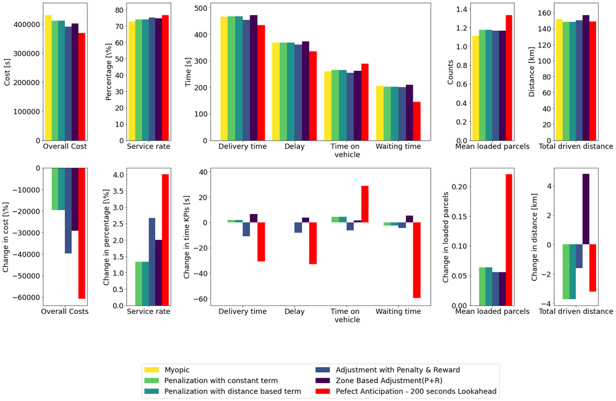

```python
plt.rcParams.update({'font.size': 18})
time_first= 9 *3600
max_hour = 9.5*3600
finishing_time = 15
time_last=max_hour+finishing_time*60
steps = 100
used_vehicles = 10
considered_depots = 5


folder_myopic = "12-11-2021_17:11:07"
folder_fruitful_myopic_nt = '15-11-2021_13:27:38'
folder_fruitful_myopic_nt_d = '15-11-2021_16:03:52'
folder_fruitful_myopic_nt_d_prc = '16-11-2021_11:32:01'
folder_fruitful_zone_nt = "17-11-2021_14:06:23"
folder_pa = "12-10-2021_13:44:54"

output_folders = [folder_myopic, folder_fruitful_myopic_nt, folder_fruitful_myopic_nt_d, folder_fruitful_myopic_nt_d_prc, folder_fruitful_zone_nt,folder_pa]

data_columns = ["Myopic", "Penalization with constant term", "Penalization with distance based term", "Adjustment with Penalty & Reward", "Zone Based Adjustment(P+R)", "Pefect Anticipation - 200 seconds Lookahead"]

base_path = "/home/stavya/Desktop/Old set up data/deliver_fastest/output/amsterdam"
data_path = "/home/stavya/Desktop/Old set up data/deliver_fastest/data/"
input_folder = "12-10-21_11:47:53"
color_map = colors.ListedColormap(['#fde725','#5ec962','#21918c','#3b528b','#440154','red'])


folder_costs = []
label_costs = []

for i,item in enumerate(output_folders):
    try:
        if item != '':
            folder_costs.append(item)
            label_costs.append(data_columns[i])
    except:
        pass

demand, demand_time = load_demand(data_path, input_folder)

delivery_time_stores, delay_stores, TimeOnVehicle_stores, WaitingToPickUp_stores, delivered, overall_cost, mean_parcels_stores, driven_distance_stores, service_rate_stores = load_graph_kpis(folder_costs, demand_time)

dif_overall, dif_delivery, dif_delay, dif_veh, dif_wait, dif_service, dif_dist, dif_parcels, dif_delivery_perorder = load_graph_index(delivery_time_stores, delay_stores, TimeOnVehicle_stores, WaitingToPickUp_stores, delivered, overall_cost, mean_parcels_stores, driven_distance_stores, service_rate_stores)

bar_computer(folder_costs, label_costs, i+1, delivery_time_stores, delay_stores, TimeOnVehicle_stores, WaitingToPickUp_stores, delivered, overall_cost, mean_parcels_stores, driven_distance_stores, service_rate_stores, dif_overall, dif_delivery, dif_delay, dif_veh, dif_wait, dif_service, dif_dist, dif_parcels, dif_delivery_perorder, color_map)
```

From the graph it is clear that the adjustment with either penalty and rewards using dynamic adjustment costs offers a service rate improvement of about 2.5% over the myopic case when the dataset has a gaussian time distribution. The method provides adjustment by penalising any routes that move away from high demand zones and in specific cases rewarding vehicle routes that end towards higher demand zones. In this case, a high demand zone is specified when the first node of the route lies in a region that has at least 15% of all candidate locations within a 100 second radius excluding any candidates on the first node itself. Further, if the first node has no single candidate in its vicinity, then the route is rewarded if the last node of the route is within a 100 second vicinity of any candidate.

# Analysis on a realistic data set

```python
output_folders_all = []
input_folders_all = []
```

### Comparitive Performance

#### Instance 1

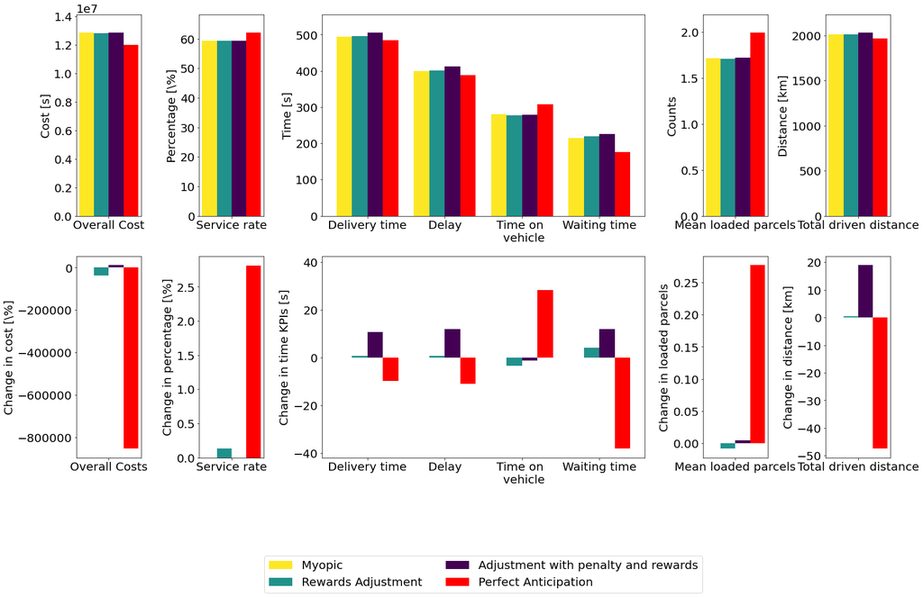

```python
plt.rcParams.update({'font.size': 20})
time_first= 9 *3600
max_hour = 17*3600
finishing_time = 15
time_last=max_hour+finishing_time*60
steps = 100
used_vehicles = 10
considered_depots = 5

folder_myopic = "20-01-2022_15:08:55"
folder_ra = "21-01-2022_06:21:09" # deprecated, running again
# folder_ra_routing = "20-01-2022_15:43:22"
folder_pa = "20-01-2022_16:42:40"
folder_perfect = "23-01-2022_11:34:29"

output_folders = [folder_myopic, folder_ra, folder_pa, folder_perfect]
output_folders_all.append(output_folders)
# output_folders2 =

data_columns = ["Myopic", "Rewards Adjustment", "Adjustment with penalty and rewards", "Perfect Anticipation"]

base_path = "/home/stavya/Desktop/deliver_fastest_real/output/amsterdam"
data_path = "/home/stavya/Desktop/deliver_fastest_real/Data_Generation/data/amsterdam"

input_folder = "20-01-22_14:59:49"
input_folders_all.append(input_folder)
color_map = colors.ListedColormap(['#fde725','#21918c','#440154','red'])


folder_costs = []
label_costs = []

for i,item in enumerate(output_folders):
    try:
        if item != '':
            folder_costs.append(item)
            label_costs.append(data_columns[i])
    except:
        pass
demand, demand_time = load_demand(data_path, input_folder)



delivery_time_stores, delay_stores, TimeOnVehicle_stores, WaitingToPickUp_stores, delivered, overall_cost, mean_parcels_stores, driven_distance_stores, service_rate_stores = load_graph_kpis(folder_costs, demand_time)

dif_overall, dif_delivery, dif_delay, dif_veh, dif_wait, dif_service, dif_dist, dif_parcels, dif_delivery_perorder = load_graph_index(delivery_time_stores, delay_stores, TimeOnVehicle_stores, WaitingToPickUp_stores, delivered, overall_cost, mean_parcels_stores, driven_distance_stores, service_rate_stores)

bar_computer(folder_costs, label_costs, 0, delivery_time_stores, delay_stores, TimeOnVehicle_stores, WaitingToPickUp_stores, delivered, overall_cost, mean_parcels_stores, driven_distance_stores, service_rate_stores, dif_overall, dif_delivery, dif_delay, dif_veh, dif_wait, dif_service, dif_dist, dif_parcels, dif_delivery_perorder, color_map)

# bar_computer(folder_costs[:3], label_costs, 0, delivery_time_stores[:3], delay_stores[:3], TimeOnVehicle_stores[:3], WaitingToPickUp_stores[:3], delivered, overall_cost[:3], mean_parcels_stores[:3], driven_distance_stores[:3], service_rate_stores[:3], dif_overall[:3], dif_delivery[:3], dif_delay[:3], dif_veh[:3], dif_wait[:3], dif_service[:3], dif_dist[:3], dif_parcels[:3], dif_delivery_perorder[:3], color_map)
```

#### Instance 2

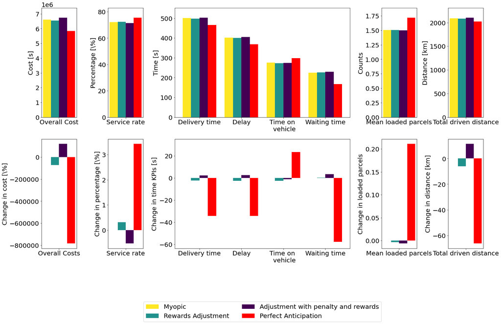

```python
plt.rcParams.update({'font.size': 20})
time_first= 9 *3600
max_hour = 17*3600
finishing_time = 15
time_last=max_hour+finishing_time*60
steps = 100
used_vehicles = 10
considered_depots = 5

folder_myopic = "20-01-2022_13:19:44"
folder_ra = "21-01-2022_06:59:52"   #deprecated, running again
# folder_ra_routing = "20-01-2022_13:51:00"
folder_pa = "20-01-2022_14:33:50"
folder_perfect = "25-01-2022_14:47:20"

output_folders = [folder_myopic, folder_ra, folder_pa, folder_perfect]
output_folders_all.append(output_folders)

data_columns = ["Myopic", "Rewards Adjustment", "Adjustment with penalty and rewards", "Perfect Anticipation"]

base_path = "/home/stavya/Desktop/deliver_fastest_real/output/amsterdam"
data_path = "/home/stavya/Desktop/deliver_fastest_real/Data_Generation/data/amsterdam"

input_folder = "20-01-22_12:59:09"
input_folders_all.append(input_folder)

color_map = colors.ListedColormap(['#fde725','#21918c','#440154','red'])


folder_costs = []
label_costs = []

for i,item in enumerate(output_folders):
    try:
        if item != '':
            folder_costs.append(item)
            label_costs.append(data_columns[i])
    except:
        pass
demand, demand_time = load_demand(data_path, input_folder)



delivery_time_stores, delay_stores, TimeOnVehicle_stores, WaitingToPickUp_stores, delivered, overall_cost, mean_parcels_stores, driven_distance_stores, service_rate_stores = load_graph_kpis(folder_costs, demand_time)

dif_overall, dif_delivery, dif_delay, dif_veh, dif_wait, dif_service, dif_dist, dif_parcels, dif_delivery_perorder = load_graph_index(delivery_time_stores, delay_stores, TimeOnVehicle_stores, WaitingToPickUp_stores, delivered, overall_cost, mean_parcels_stores, driven_distance_stores, service_rate_stores)

bar_computer(folder_costs, label_costs, 0, delivery_time_stores, delay_stores, TimeOnVehicle_stores, WaitingToPickUp_stores, delivered, overall_cost, mean_parcels_stores, driven_distance_stores, service_rate_stores, dif_overall, dif_delivery, dif_delay, dif_veh, dif_wait, dif_service, dif_dist, dif_parcels, dif_delivery_perorder, color_map)

# bar_computer(folder_costs[:3], label_costs, 0, delivery_time_stores[:3], delay_stores[:3], TimeOnVehicle_stores[:3], WaitingToPickUp_stores[:3], delivered, overall_cost[:3], mean_parcels_stores[:3], driven_distance_stores[:3], service_rate_stores[:3], dif_overall[:3], dif_delivery[:3], dif_delay[:3], dif_veh[:3], dif_wait[:3], dif_service[:3], dif_dist[:3], dif_parcels[:3], dif_delivery_perorder[:3], color_map)
```

#### Instance 3

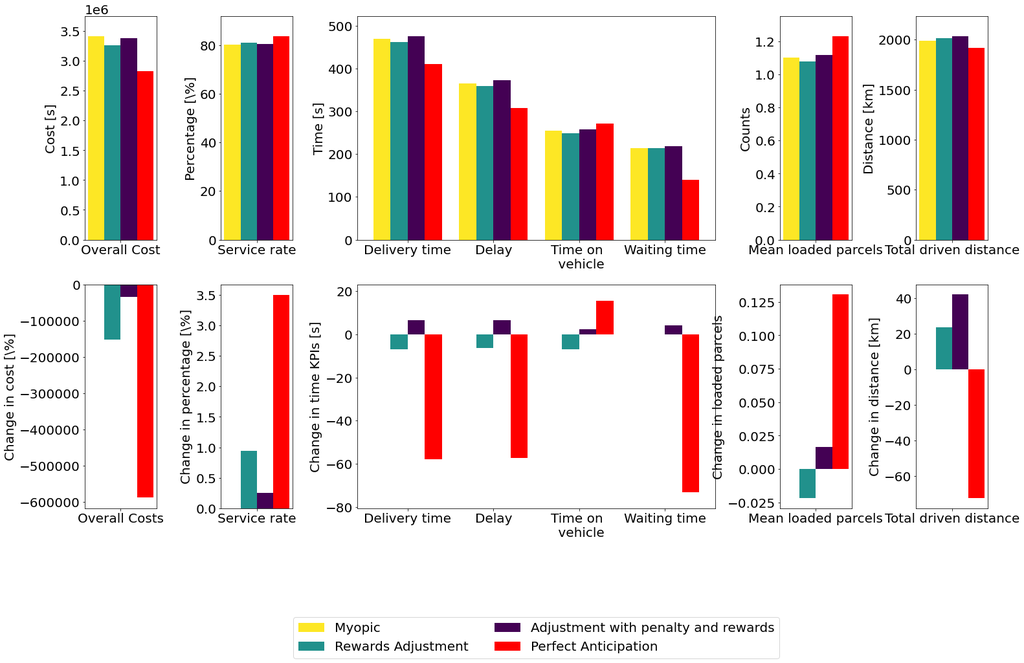

```python
plt.rcParams.update({'font.size': 20})
time_first= 9 *3600
max_hour = 17*3600
finishing_time = 15
time_last=max_hour+finishing_time*60
steps = 100
used_vehicles = 10
considered_depots = 5

folder_myopic = "24-01-2022_06:43:54"
folder_ra = "27-01-2022_15:46:29"
# folder_ra_routing = #"24-01-2022_10:32:29"
folder_pa = "24-01-2022_07:06:01"
folder_perfect = "24-01-2022_07:17:21"

output_folders = [folder_myopic, folder_ra, folder_pa, folder_perfect]
output_folders_all.append(output_folders)

data_columns = ["Myopic", "Rewards Adjustment", "Adjustment with penalty and rewards", "Perfect Anticipation"]

base_path = "/home/stavya/Desktop/deliver_fastest_real/output/amsterdam"
data_path = "/home/stavya/Desktop/deliver_fastest_real/Data_Generation/data/amsterdam"

input_folder = "23-01-22_10:50:22"
input_folders_all.append(input_folder)

color_map = colors.ListedColormap(['#fde725','#21918c','#440154','red'])


folder_costs = []
label_costs = []

for i,item in enumerate(output_folders):
    try:
        if item != '':
            folder_costs.append(item)
            label_costs.append(data_columns[i])
    except:
        pass
demand, demand_time = load_demand(data_path, input_folder)



delivery_time_stores, delay_stores, TimeOnVehicle_stores, WaitingToPickUp_stores, delivered, overall_cost, mean_parcels_stores, driven_distance_stores, service_rate_stores = load_graph_kpis(folder_costs, demand_time)

dif_overall, dif_delivery, dif_delay, dif_veh, dif_wait, dif_service, dif_dist, dif_parcels, dif_delivery_perorder = load_graph_index(delivery_time_stores, delay_stores, TimeOnVehicle_stores, WaitingToPickUp_stores, delivered, overall_cost, mean_parcels_stores, driven_distance_stores, service_rate_stores)

bar_computer(folder_costs, label_costs, 0, delivery_time_stores, delay_stores, TimeOnVehicle_stores, WaitingToPickUp_stores, delivered, overall_cost, mean_parcels_stores, driven_distance_stores, service_rate_stores, dif_overall, dif_delivery, dif_delay, dif_veh, dif_wait, dif_service, dif_dist, dif_parcels, dif_delivery_perorder, color_map)

# bar_computer(folder_costs[:3], label_costs, 0, delivery_time_stores[:3], delay_stores[:3], TimeOnVehicle_stores[:3], WaitingToPickUp_stores[:3], delivered, overall_cost[:3], mean_parcels_stores[:3], driven_distance_stores[:3], service_rate_stores[:3], dif_overall[:3], dif_delivery[:3], dif_delay[:3], dif_veh[:3], dif_wait[:3], dif_service[:3], dif_dist[:3], dif_parcels[:3], dif_delivery_perorder[:3], color_map)
```

#### Instance 4

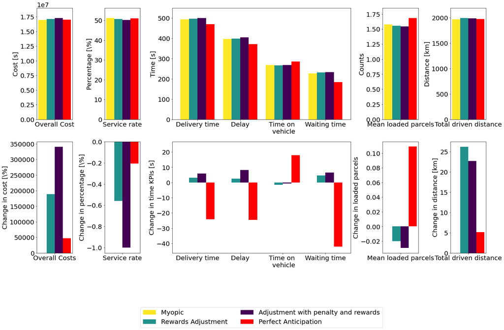

```python
plt.rcParams.update({'font.size': 20})
time_first= 9 *3600
max_hour = 17*3600
finishing_time = 15
time_last=max_hour+finishing_time*60
steps = 100
used_vehicles = 10
considered_depots = 5

folder_myopic = "24-01-2022_09:45:35"
folder_ra = "27-01-2022_15:58:34"
# folder_ra_routing = "20-01-2022_13:51:00"
folder_pa = "24-01-2022_15:46:04"
folder_perfect1 = "24-01-2022_18:51:57"
# folder_perfect2 = '25-01-2022_10:55:03'

output_folders = [folder_myopic, folder_ra, folder_pa, folder_perfect1]
output_folders_all.append(output_folders)

data_columns = ["Myopic", "Rewards Adjustment", "Adjustment with penalty and rewards", "Perfect Anticipation"]

base_path = "/home/stavya/Desktop/deliver_fastest_real/output/amsterdam"
data_path = "/home/stavya/Desktop/deliver_fastest_real/Data_Generation/data/amsterdam"

input_folder = "24-01-22_09:32:04"
input_folders_all.append(input_folder)

color_map = colors.ListedColormap(['#fde725','#21918c','#440154','red'])


folder_costs = []
label_costs = []

for i,item in enumerate(output_folders):
    try:
        if item != '':
            folder_costs.append(item)
            label_costs.append(data_columns[i])
    except:
        pass
demand, demand_time = load_demand(data_path, input_folder)



delivery_time_stores, delay_stores, TimeOnVehicle_stores, WaitingToPickUp_stores, delivered, overall_cost, mean_parcels_stores, driven_distance_stores, service_rate_stores = load_graph_kpis(folder_costs, demand_time)

dif_overall, dif_delivery, dif_delay, dif_veh, dif_wait, dif_service, dif_dist, dif_parcels, dif_delivery_perorder = load_graph_index(delivery_time_stores, delay_stores, TimeOnVehicle_stores, WaitingToPickUp_stores, delivered, overall_cost, mean_parcels_stores, driven_distance_stores, service_rate_stores)

bar_computer(folder_costs, label_costs, 0, delivery_time_stores, delay_stores, TimeOnVehicle_stores, WaitingToPickUp_stores, delivered, overall_cost, mean_parcels_stores, driven_distance_stores, service_rate_stores, dif_overall, dif_delivery, dif_delay, dif_veh, dif_wait, dif_service, dif_dist, dif_parcels, dif_delivery_perorder, color_map)
```

#### Perfect anticipation performance on varying RTV time out improves for Instance 4

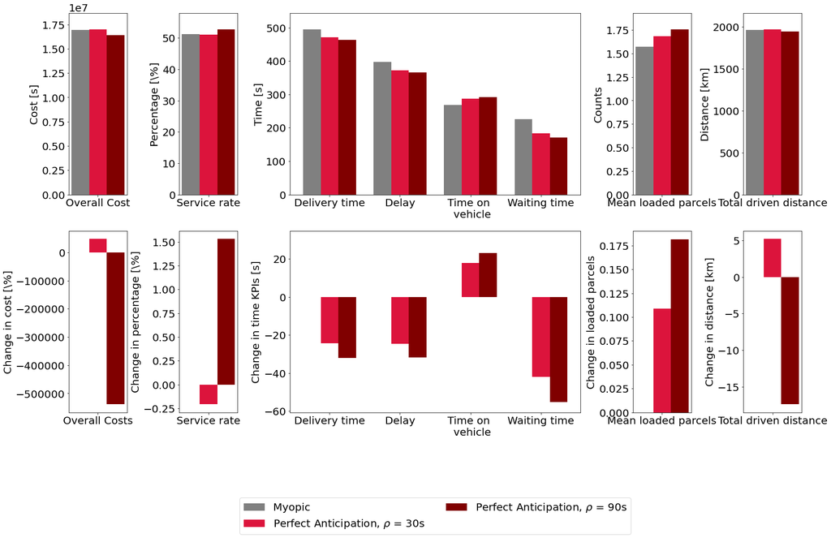

```python
plt.rcParams.update({'font.size': 20})
time_first= 9 *3600
max_hour = 17*3600
finishing_time = 15
time_last=max_hour+finishing_time*60
steps = 100
used_vehicles = 10
considered_depots = 5

folder_myopic = "24-01-2022_09:45:35"
folder_perfect1 = "24-01-2022_18:51:57"
folder_perfect2 = '25-01-2022_10:55:03'

output_folders = [ folder_myopic, folder_perfect1, folder_perfect2]

data_columns = ["Myopic", 'Perfect Anticipation, 'r'$\rho$ = 30s', 'Perfect Anticipation, 'r'$\rho$ = 90s']

base_path = "/home/stavya/Desktop/deliver_fastest_real/output/amsterdam"
data_path = "/home/stavya/Desktop/deliver_fastest_real/Data_Generation/data/amsterdam"

input_folder = "24-01-22_09:32:04"
# input_folders_all.append(input_folder)

color_map = colors.ListedColormap(['grey','crimson','maroon'])


folder_costs = []
label_costs = []

for i,item in enumerate(output_folders):
    try:
        if item != '':
            folder_costs.append(item)
            label_costs.append(data_columns[i])
    except:
        pass
demand, demand_time = load_demand(data_path, input_folder)



delivery_time_stores, delay_stores, TimeOnVehicle_stores, WaitingToPickUp_stores, delivered, overall_cost, mean_parcels_stores, driven_distance_stores, service_rate_stores = load_graph_kpis(folder_costs, demand_time)

dif_overall, dif_delivery, dif_delay, dif_veh, dif_wait, dif_service, dif_dist, dif_parcels, dif_delivery_perorder = load_graph_index(delivery_time_stores, delay_stores, TimeOnVehicle_stores, WaitingToPickUp_stores, delivered, overall_cost, mean_parcels_stores, driven_distance_stores, service_rate_stores)

bar_computer(folder_costs, label_costs, 0, delivery_time_stores, delay_stores, TimeOnVehicle_stores, WaitingToPickUp_stores, delivered, overall_cost, mean_parcels_stores, driven_distance_stores, service_rate_stores, dif_overall, dif_delivery, dif_delay, dif_veh, dif_wait, dif_service, dif_dist, dif_parcels, dif_delivery_perorder, color_map)
```

#### Highlighting waiting in perfect anticipation

```python
dirpath = os.path.join(base_path,folder_perfect2 + "/vehicles")
time_list = np.linspace(time_first, time_last, int((time_last-time_first)/steps+1))[1:-2]
waiting_time = pd.DataFrame(columns=range(10))
#     if steps == 140:
#         filename = 'vehicles-47180.txt'
#     else:
for i in time_list:
    filename = 'vehicles-{}.txt'.format(int(i))
    veh_current = []

    with open(os.path.join(dirpath, filename), 'r') as txt:
        all_txt = txt.read()
        lines = all_txt.split("#")
        lines.remove(lines[0])
        lines = lines[0].split("\n")
        lines.remove(lines[0])

        for i in lines[:used_vehicles]:
            veh = []
            new = i.split("%")
            if new == ['']:
                break
            else:
                wait = new[7]
                veh.append(int(wait))
                veh_current.append(veh)
        waiting_time = waiting_time.append(pd.DataFrame(np.reshape(np.array(veh_current),(1,-1))))
```

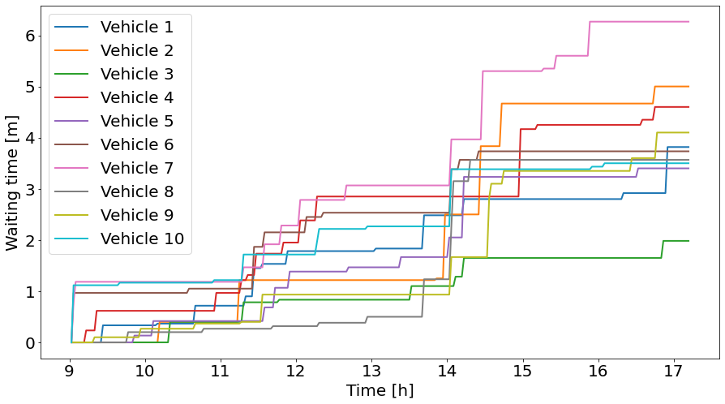

```python
plt.figure(figsize=(15,8))
for i in waiting_time:
    plt.plot(time_list/3600,waiting_time[i]/60,label='Vehicle ' + str(i+1), linewidth=2)
plt.legend()
plt.ylabel('Waiting time [m]')
plt.xlabel('Time [h]')
```

#### Instance 5

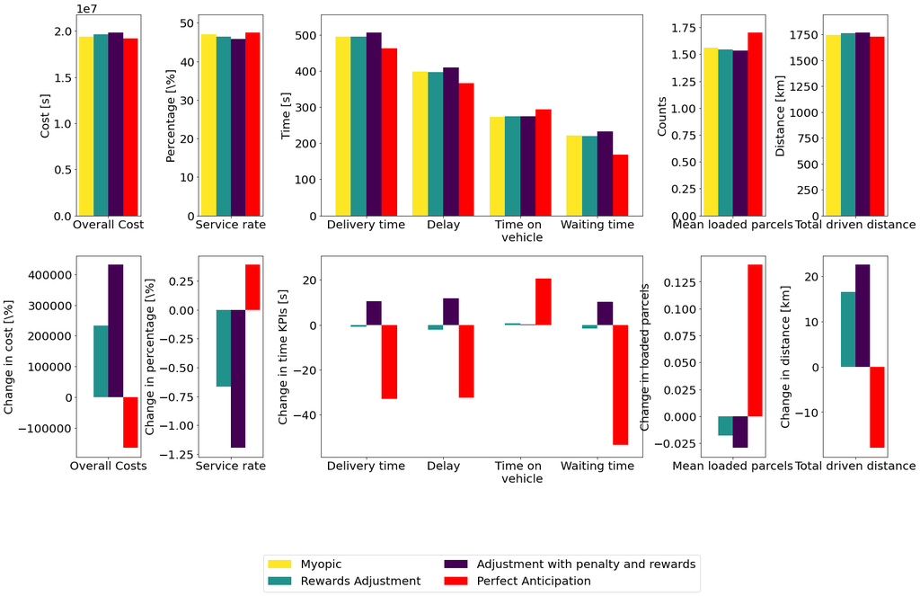

```python
plt.rcParams.update({'font.size': 20})
time_first= 9 *3600
max_hour = 17*3600
finishing_time = 15
time_last=max_hour+finishing_time*60
steps = 100
used_vehicles = 10
considered_depots = 5

folder_myopic = "25-01-2022_00:25:06"
folder_ra = "27-01-2022_19:20:46"
# folder_ra_routing = "25-01-2022_15:41:09"
folder_pa = "25-01-2022_06:05:19"
folder_perfect = "25-01-2022_09:00:29"

output_folders = [folder_myopic, folder_ra, folder_pa, folder_perfect]
output_folders_all.append(output_folders)

data_columns = ["Myopic", "Rewards Adjustment", "Adjustment with penalty and rewards", "Perfect Anticipation"]

base_path = "/home/stavya/Desktop/deliver_fastest_real/output/amsterdam"
data_path = "/home/stavya/Desktop/deliver_fastest_real/Data_Generation/data/amsterdam"

input_folder = "24-01-22_09:37:56"
input_folders_all.append(input_folder)
color_map = colors.ListedColormap(['#fde725','#21918c','#440154','red'])


folder_costs = []
label_costs = []

for i,item in enumerate(output_folders):
    try:
        if item != '':
            folder_costs.append(item)
            label_costs.append(data_columns[i])
    except:
        pass
demand, demand_time = load_demand(data_path, input_folder)



delivery_time_stores, delay_stores, TimeOnVehicle_stores, WaitingToPickUp_stores, delivered, overall_cost, mean_parcels_stores, driven_distance_stores, service_rate_stores = load_graph_kpis(folder_costs, demand_time)

dif_overall, dif_delivery, dif_delay, dif_veh, dif_wait, dif_service, dif_dist, dif_parcels, dif_delivery_perorder = load_graph_index(delivery_time_stores, delay_stores, TimeOnVehicle_stores, WaitingToPickUp_stores, delivered, overall_cost, mean_parcels_stores, driven_distance_stores, service_rate_stores)

bar_computer(folder_costs, label_costs, 0, delivery_time_stores, delay_stores, TimeOnVehicle_stores, WaitingToPickUp_stores, delivered, overall_cost, mean_parcels_stores, driven_distance_stores, service_rate_stores, dif_overall, dif_delivery, dif_delay, dif_veh, dif_wait, dif_service, dif_dist, dif_parcels, dif_delivery_perorder, color_map)
```

One explaination for this could be that with rewards adjustment, the vehicles are able to serve even those orders that were typically rejected because of the constraints in waiting time. This increases the average waiting time.

Questions:

We further, deep dive into one realistic data set scenario -

### Status Parcels Comparison

```python
time_list = np.linspace(time_first, time_last, int((time_last-time_first)/steps+1))[2:-1]
time_list_plot = time_list/3600
```

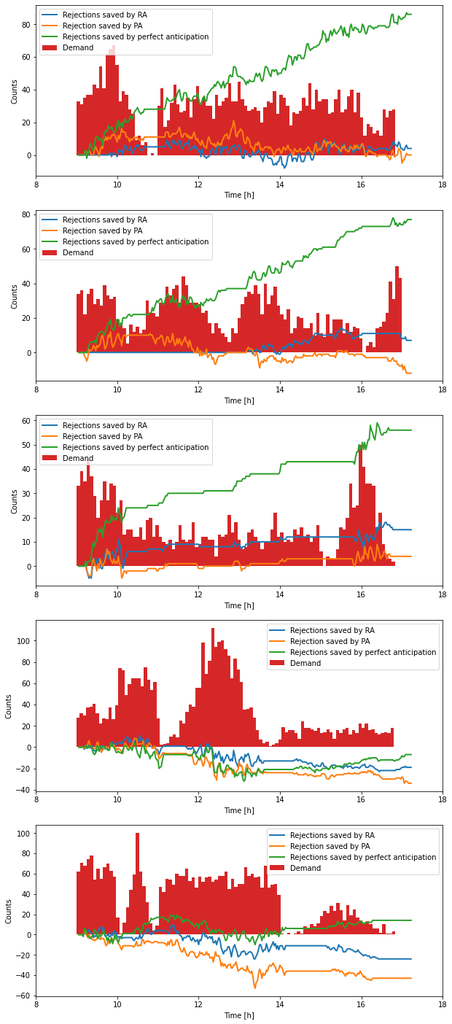

```python
plt.rcParams.update({'font.size': 10})

KPI_fn = "KPIs.csv"
plt.figure(figsize=(10,25))

for num, folder_list in enumerate(output_folders_all):

    pickups_all, drops_all, ignored_all, open_order_all, rebalancing_all = [], [], [], [], []

    for i in folder_list: #TODO: Replace with real data set folders
        if i == "":
            break
        with open(os.path.join(base_path,i, KPI_fn), 'r') as f:
            kpi = list(csv.reader(f, delimiter=','))
            #print(kpi[0])
            kpi = kpi[1:] #drop the length of array


        pickups, drops, ignored, open_order, rebalancing = [],[],[],[],[]
        for time in kpi:
            #print(time)
            open_order.append(int(time[1]))
            pickups.append(int(time[2]))
            drops.append(int(time[3]))
            ignored.append(int(time[4])/5) # is calculated based on requests
            rebalancing.append(int(time[5]))

        pickups_all.append(pickups)
        drops_all.append(drops)
        ignored_all.append(ignored)
        open_order_all.append(open_order)
        rebalancing_all.append(rebalancing)

    # fig, ax = fp.newfig(1)
    plt.subplot(5,1,num+1)
    bins = np.linspace(np.min(demand_time/3600),np.max(demand_time/3600), 100)

    demand, demand_time = load_demand(data_path, input_folders_all[num])

    ax = plt
    # for num in range(2): # Replace with real data set folders
    ax.plot(time_list_plot, rolling_sum(np.subtract(ignored_all[0],ignored_all[1])), label="Rejections saved by RA", linewidth=2)
    # ax.plot(time_list_plot, rolling_sum(np.subtract(ignored_all[0],ignored_all[2])), label="Rejections saved by RA-routing", linewidth=2)
    ax.plot(time_list_plot, rolling_sum(np.subtract(ignored_all[0],ignored_all[2])), label="Rejection saved by PA", linewidth=2)
    ax.plot(time_list_plot, rolling_sum(np.subtract(ignored_all[0],ignored_all[3])), label="Rejections saved by perfect anticipation", linewidth=2)
    ax.hist(demand_time/3600, bins, label='Demand')
    #ax.title.set_text("Demand Distribution")
    plt.legend( fancybox=True, shadow=False, )
    ax.xlim(8,18)
    ax.xlabel("Time [h]")
    ax.ylabel("Counts")

    # ax.set_xlim(0,12)
```

# Analysis on realistic data set - Parameter analysis

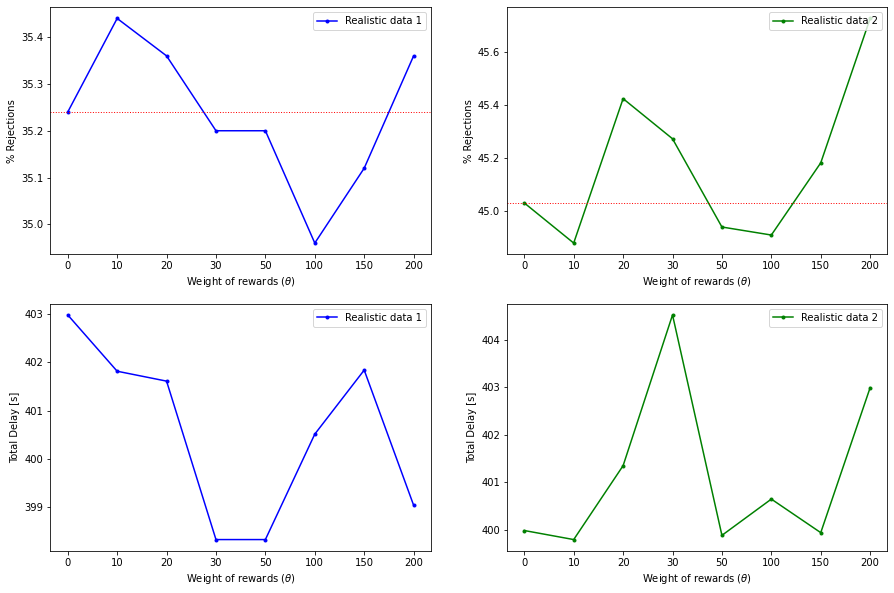

```python
ra_200 = "22-01-2022_10:30:26"
ra_150 = "22-01-2022_09:54:09" # - 150
ra_100 = "21-01-2022_06:59:52" #- 100
ra_50 =  "22-01-2022_09:22:10" #- 50
ra_30 =  "22-01-2022_08:50:10" #- 30
ra_20 =  "22-01-2022_08:18:18" #- 20
ra_10 =  "22-01-2022_07:45:50" #- 10
myopic = "20-01-2022_13:19:44" #- myopic

output_folders = [myopic, ra_10, ra_20, ra_30, ra_50, ra_100, ra_150, ra_200]


base_path = "/home/stavya/Desktop/deliver_fastest_real/output/amsterdam"
data_path = "/home/stavya/Desktop/deliver_fastest_real/Data_Generation/data/amsterdam"
input_folder = "20-01-22_12:59:09"



folder_costs = []
label_costs = []

for i,item in enumerate(output_folders):
    try:
        if item != '':
            folder_costs.append(item)
            label_costs.append(data_columns[i])
    except:
        pass
demand, demand_time = load_demand(data_path, input_folder)



delivery_time_stores, delay_stores, TimeOnVehicle_stores, WaitingToPickUp_stores, delivered, overall_cost, mean_parcels_stores, driven_distance_stores, service_rate_stores = load_graph_kpis(folder_costs, demand_time)

dif_overall, dif_delivery, dif_delay, dif_veh, dif_wait, dif_service, dif_dist, dif_parcels, dif_delivery_perorder = load_graph_index(delivery_time_stores, delay_stores, TimeOnVehicle_stores, WaitingToPickUp_stores, delivered, overall_cost, mean_parcels_stores, driven_distance_stores, service_rate_stores)

rejected = (np.array(len(demand)) - delivered)/len(demand)

ra_200 = "22-01-2022_13:46:05"
ra_150 = "22-01-2022_13:14:16" # - 150
ra_100 = "21-01-2022_06:21:09" #- 100
ra_50 =  "22-01-2022_12:41:43" #- 50
ra_30 =  "22-01-2022_12:11:27" #- 30
ra_20 =  "22-01-2022_11:44:20" #- 20
ra_10 =  "22-01-2022_11:10:19" #- 10
myopic = "20-01-2022_15:08:55" #- myopic

output_folders = [myopic, ra_10, ra_20, ra_30, ra_50, ra_100, ra_150, ra_200]
input_folder = "20-01-22_14:59:49"



folder_costs = []
label_costs = []

for i,item in enumerate(output_folders):
    try:
        if item != '':
            folder_costs.append(item)
            label_costs.append(data_columns[i])
    except:
        pass
demand, demand_time = load_demand(data_path, input_folder)



delivery_time_stores, delay_stores_2, TimeOnVehicle_stores, WaitingToPickUp_stores, delivered, overall_cost, mean_parcels_stores, driven_distance_stores, service_rate_stores = load_graph_kpis(folder_costs, demand_time)

dif_overall, dif_delivery, dif_delay, dif_veh, dif_wait, dif_service, dif_dist, dif_parcels, dif_delivery_perorder = load_graph_index(delivery_time_stores, delay_stores, TimeOnVehicle_stores, WaitingToPickUp_stores, delivered, overall_cost, mean_parcels_stores, driven_distance_stores, service_rate_stores)

rejected_2 = (np.array(len(demand)) - delivered)/len(demand)


plt.figure(figsize=(15,10))
plt.subplot(2,2,1)
plt.plot(['0', '10', '20', '30', '50', '100', '150', '200'],rejected*100,'b.-', label='Realistic data 1'  )
plt.axhline(y=rejected[0]*100, color='red', linestyle='dotted', linewidth=1)
plt.ylabel('% Rejections')
plt.xlabel('Weight of rewards ('r'$\theta$)')
plt.legend(loc="upper right")


plt.subplot(2,2,2)
plt.plot(['0', '10', '20', '30', '50', '100', '150', '200'],rejected_2*100,'g.-', label='Realistic data 2'  )
plt.axhline(y=rejected_2[0]*100, color='red', linestyle='dotted', linewidth=1)
plt.ylabel('% Rejections')
plt.xlabel('Weight of rewards ('r'$\theta$)')
plt.legend(loc="upper right")

plt.subplot(2,2,3)
plt.plot(['0', '10', '20', '30', '50', '100', '150', '200'],delay_stores,'b.-', label='Realistic data 1'  )
plt.ylabel('Total Delay [s]')
plt.xlabel('Weight of rewards ('r'$\theta$)')
plt.legend(loc="upper right")

plt.subplot(2,2,4)
plt.plot(['0', '10', '20', '30', '50', '100', '150', '200'],delay_stores_2,'g.-', label='Realistic data 2'  )
plt.ylabel('Total Delay [s]')
plt.xlabel('Weight of rewards ('r'$\theta$)')
plt.legend(loc="upper right")
```

We analysed the rewards adjustment for different parameters of the reward. Takeaway-

As such, it appears that the parameter theta is sensitive to the demand instance being used with the impact of rewards varying phenomenally with different theta values. This makes the selection of a robust tuning parameter a non-trivial endeavour requiring constant alteration to suit the underlying demand patterns. As such values between 50-100 offer an improvement over theta =0 which is the myopic simulation. In both the simulations, increasing values beyond 100 tends to diminish the results as a result of over-compensation of the anticipatory approach and sacrifice of optimal trips to push vehicles close to the depot routes. A comprehensive study of altering theta with respect to underlying demand may be imperative to fully extract the benefit of the proposed anticipatory technique.